# Housing_Price

```r
model5 <- lm(formula=log(price)~bathrooms+grade+floors+
           newsqft_living+crimerate+Distance,data=train2.data)
summary(model5)
```

```
##
## Call:
## lm(formula = log(price) ~ bathrooms + grade + floors + newsqft_living +
##     crimerate + Distance, data = train2.data)
##
## Residuals:
##      Min       1Q   Median       3Q      Max
## -1.20876 -0.18225  0.00391  0.17451  1.49032
##
## Coefficients:
##                  Estimate Std. Error t value Pr(>|t|)
## (Intercept)     1.154e+01  1.754e-02 657.743  < 2e-16 ***
## bathrooms       5.180e-02  4.472e-03  11.583  < 2e-16 ***
## grade           1.698e-01  3.062e-03  55.466  < 2e-16 ***
## floors         -3.635e-02  4.888e-03  -7.437 1.08e-13 ***
## newsqft_living  2.275e-04  4.283e-06  53.114  < 2e-16 ***
## crimerate      -4.659e+00  1.174e-01 -39.695  < 2e-16 ***
## Distance       -1.429e-02  1.969e-04 -72.534  < 2e-16 ***
## ---
## Signif. codes:  0 '***' 0.001 '**' 0.01 '*' 0.05 '.' 0.1 ' ' 1
##
## Residual standard error: 0.291 on 17281 degrees of freedom
## Multiple R-squared:  0.6953, Adjusted R-squared:  0.6952
## F-statistic:  6573 on 6 and 17281 DF,  p-value: < 2.2e-16
```

predicting the price for test data using model5

```r
y5<-exp(predict.glm(model5,test2.data))
```

Calculating rmse for predicted and observed values using model5

```r
y=test2.data[,3]
rmse5= sqrt((y-y5)%*%(y-y5))/nrow(test2.data)
rmse5
```

```
##        [,1]
## [1,] 3121.9
```

Residual Plots model5 Residual plot normality

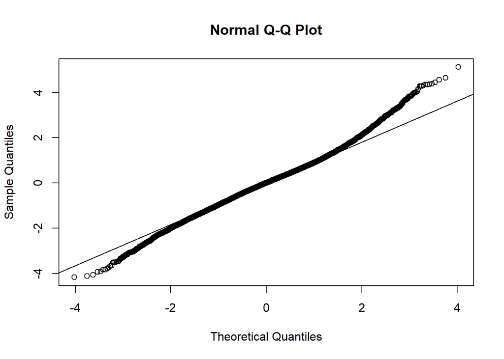

```r
qqnorm(rstandard(model5))
qqline(rstandard(model5,col="red"))
```

plot between residual and predicted

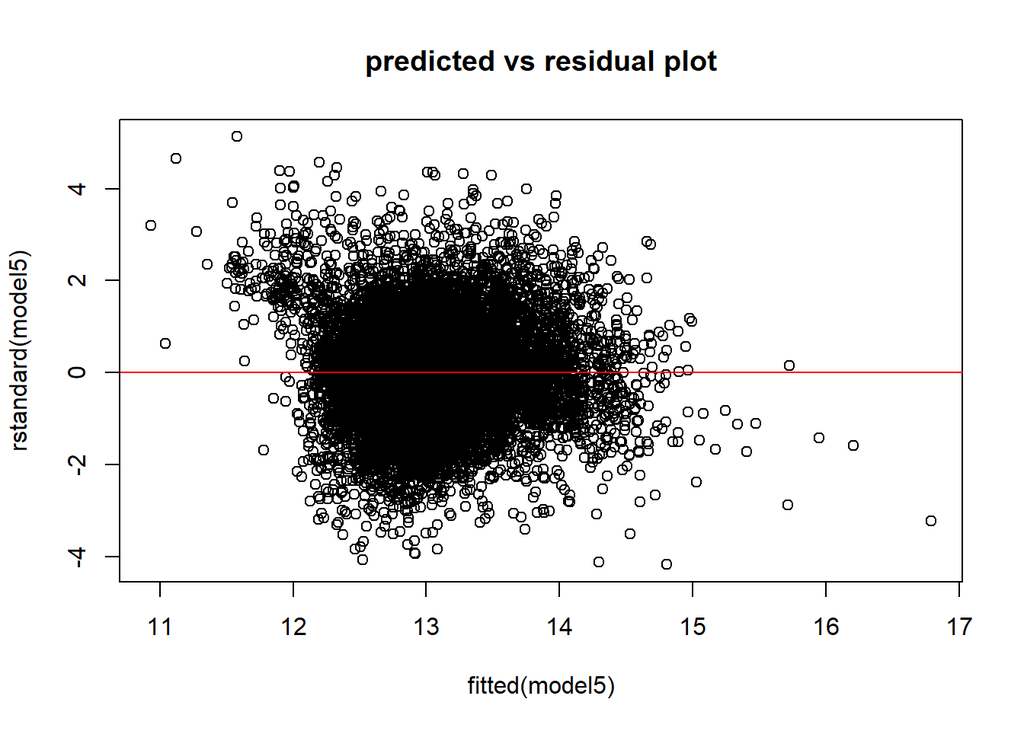

```r
plot(fitted(model5),rstandard(model5),main="predicted vs residual plot")
abline(a=0, b=0, col='red')
```

Calculating price persqft

```r
fulldata$pricepersqft <- fulldata$price/fulldata$newsqft_living
names(fulldata)
```

```
##  [1] "zipcode"        "Distance"       "Income"         "time"
##  [5] "population"     "crime.count"    "burglary"       "theft"
##  [9] "b.t"            "id"             "date"           "Date.only"
## [13] "price"          "bedrooms"       "bathrooms"      "sqft_living"
## [17] "sqft_lot"       "floors"         "waterfront"     "view"
## [21] "condition"      "grade"          "sqft_above"     "sqft_basement"
## [25] "yr_built"       "yr_renovated"   "lat"            "long"
## [29] "sqft_living15"  "sqft_lot15"     "Age"            "year"
## [33] "newsqft_living" "newsqft_lot"    "crimerate"      "pricepersqft"
```

Analysing distance

```r
summary(fulldata$Distance)
```

```
##    Min. 1st Qu.  Median    Mean 3rd Qu.    Max.
##    0.00    8.50   15.85   17.31   22.49   79.83
```

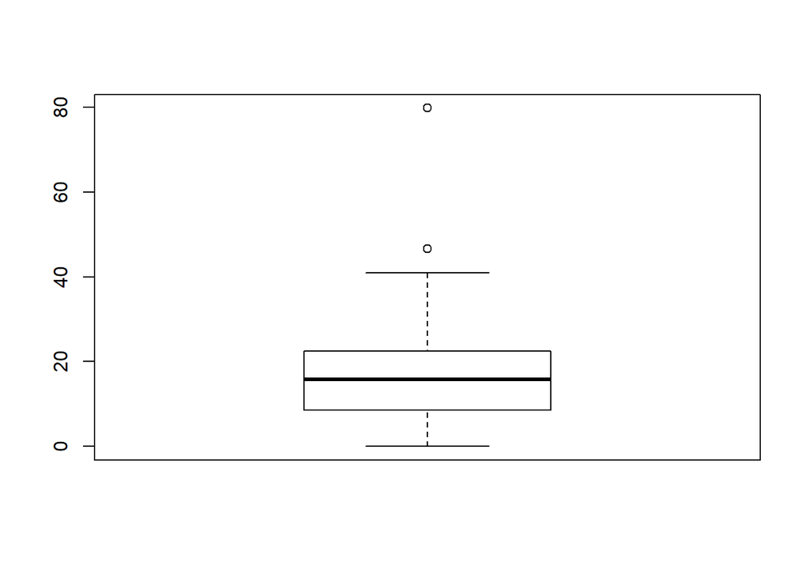

```r
boxplot(fulldata$Distance)
```

```r
names(fulldata)
```

```
##  [1] "zipcode"        "Distance"       "Income"         "time"
##  [5] "population"     "crime.count"    "burglary"       "theft"
##  [9] "b.t"            "id"             "date"           "Date.only"
## [13] "price"          "bedrooms"       "bathrooms"      "sqft_living"
## [17] "sqft_lot"       "floors"         "waterfront"     "view"
## [21] "condition"      "grade"          "sqft_above"     "sqft_basement"
## [25] "yr_built"       "yr_renovated"   "lat"            "long"
## [29] "sqft_living15"  "sqft_lot15"     "Age"            "year"
## [33] "newsqft_living" "newsqft_lot"    "crimerate"      "pricepersqft"
```

Storing distance and price in a new dataset

```r
hypdistance<- fulldata[c(2,36)]
```

First sample with zipcodes less then median distance from Amazon head quartes

```r
x<- subset(hypdistance,Distance <= 15.85)
```

Second sample with zipcodes gretera then median distance from Amazon head quartes

```r
y<- subset(hypdistance,Distance > 15.85)
```

Assiging pricepersqft of two samples to x and y varaibles

```r
x <- x$pricepersqft
y<- y$pricepersqft
```

Hypothesis for distance Null Hypothesis -No Average differnece in house price based on Distance Alternate Hypothesis -There is Average difference in house pricesummary

Standard deviation of X

```r
sd(x)
```

```
## [1] 121.7353
```

Standard deviation of Y

```r
sd(y)
```

```
## [1] 76.98242
```

```r
t.test(x,sigma.x=121.73 ,y,sigma.y=76.98 ,alternative="two.sided" ,conf.level=0.95)
```

```
##
##  Welch Two Sample t-test
##
## data:  x and y
## t = 77.53, df = 18873, p-value < 2.2e-16
## alternative hypothesis: true difference in means is not equal to 0
## 95 percent confidence interval:
##  104.1533 109.5563
## sample estimates:
## mean of x mean of y
##  317.3277  210.4729
```

```r
fulldata$pricepersqft <- fulldata$price/fulldata$newsqft_living
names(fulldata)
```

```
##  [1] "zipcode"        "Distance"       "Income"         "time"
##  [5] "population"     "crime.count"    "burglary"       "theft"
##  [9] "b.t"            "id"             "date"           "Date.only"
## [13] "price"          "bedrooms"       "bathrooms"      "sqft_living"
## [17] "sqft_lot"       "floors"         "waterfront"     "view"
## [21] "condition"      "grade"          "sqft_above"     "sqft_basement"
## [25] "yr_built"       "yr_renovated"   "lat"            "long"
## [29] "sqft_living15"  "sqft_lot15"     "Age"            "year"
## [33] "newsqft_living" "newsqft_lot"    "crimerate"      "pricepersqft"
```

Analysing crimerate

```r
summary(fulldata$crimerate)
```

```
##    Min. 1st Qu.  Median    Mean 3rd Qu.    Max.
## 0.00000 0.00000 0.00000 0.01437 0.02000 0.08000
```

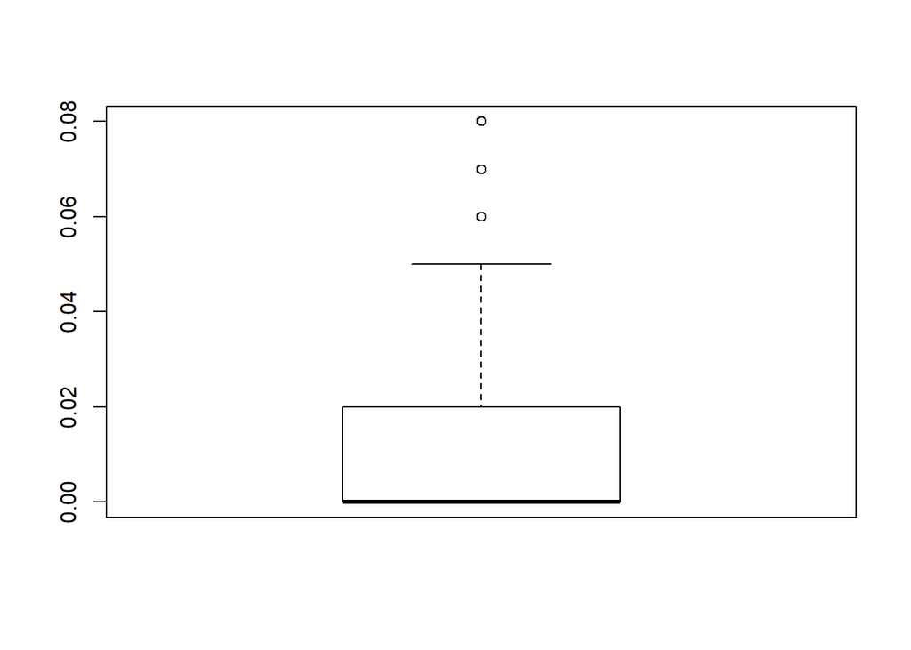

```r
boxplot(fulldata$crimerate)
```

```r
names(fulldata)
```

```
##  [1] "zipcode"        "Distance"       "Income"         "time"
##  [5] "population"     "crime.count"    "burglary"       "theft"
##  [9] "b.t"            "id"             "date"           "Date.only"
## [13] "price"          "bedrooms"       "bathrooms"      "sqft_living"
## [17] "sqft_lot"       "floors"         "waterfront"     "view"
## [21] "condition"      "grade"          "sqft_above"     "sqft_basement"
## [25] "yr_built"       "yr_renovated"   "lat"            "long"
## [29] "sqft_living15"  "sqft_lot15"     "Age"            "year"
## [33] "newsqft_living" "newsqft_lot"    "crimerate"      "pricepersqft"
```

Storing price per square feet and crime in a data frame

```r
hypdistance<- fulldata[c(35,36)]
```

First sample with zipcodes having crime rates lesser than median crime rate

```r
x<- subset(hypdistance,crimerate <= 0.004)
```

```r
y<- subset(hypdistance,crimerate > 0.004)
```

Assigning the price per squaree feet of two samples to x and y

```r
x<- x$pricepersqft
y<- y$pricepersqft
```

Hypothesis for crime Null Hypothesis -Crime has no effect on average price per square feet Alternate Hypothesis- Crime is contributing on average price per square feet

Standard deviation of X

```r
sd(x)
```

```
## [1] 127.7349
```

Standard deviation of Y

```r
sd(y)
```

```
## [1] 78.91234
```

```r
t.test(x,sigma.x=127.7317 ,y,sigma.y=78.9124 ,conf.level=0.95)
```

```
##
##  Welch Two Sample t-test
##
## data:  x and y
## t = 62.033, df = 18371, p-value < 2.2e-16
## alternative hypothesis: true difference in means is not equal to 0
## 95 percent confidence interval:
##  86.47902 92.12237
## sample estimates:
## mean of x mean of y
##  309.2689  219.9682
```